# Class Activity: assumptions and diagnostics

In this activity, you will practice checking the assumptions for linear regression models.

**Instructions:**

- You are welcome to work with a neighbor, but everyone must submit their own file to Canvas
- At the end of class, render the file as an HTML and submit the HTML to Canvas (let me know if you encounter any problems)

## Setup

**Template file:** ca_14_template.qmd

This activity investigates the relationship between the number of doctors in a county, and the number of hospitals. The data come from a random sample of 53 counties in the US, and are contained in the `CountyHealth` dataset from the `Stat2Data` package. The dataset includes the following variables:

- `County`: the name and state of the county
- `MDs`: the number of medical doctors in the county
- `Hospitals`: number of hospitals in the county
- `Beds`: the number of beds in the hospital

The activity template contains copies of the code below. Run the setup chunk in the template before you begin.

# Diagnostics

We are interested in the relationship between the number of hospitals and the number of doctors in a county.

Previously, we tried fitting a linear model:

$\text{doctors} = \beta_0 + \beta_1 \text{hospitals} + \varepsilon$

In R:

```r
library(Stat2Data)
data("CountyHealth")
library(tidyverse)

health_lm <- lm(MDs ~ Hospitals, data = CountyHealth)
```

We also examined a residual plot:

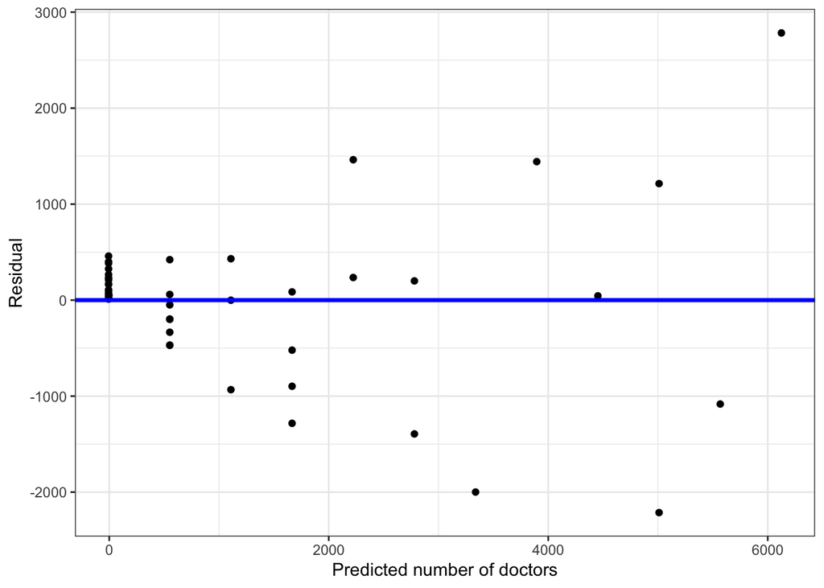

```r
data.frame(yhat = predict(health_lm),
         residuals = residuals(health_lm)) |>
  ggplot(aes(x = yhat, y = residuals)) +
  geom_point() +
  geom_abline(slope = 0, intercept = 0,
              color = "blue", lwd = 1.2) +
  labs(x = "Predicted number of doctors",
       y = "Residual") +
  theme_bw()
```

## Questions

Now let’s assess the other assumptions.

1. Run the code below to make a QQ plot for the fitted model. Does the normality assumption seem reasonable?

```r
data.frame(residuals = residuals(health_lm)) |>
  ggplot(aes(sample = residuals)) +
  geom_qq() +
  geom_qq_line() +
  labs(x = "Theoretical normal quantiles",
       y = "Observed residual quantiles") +
  theme_classic()
```

2. To address violations of the linear regression assumptions, we have discussed transformations. Fit a linear model with the *square root* of the number of doctors as the response:

```r
health_lm <- lm(MDs ~ Hospitals, data = CountyHealth)
```

3. Re-make the residual plot and QQ plot. How do the shape, constant variance, and normality assumptions look now?

### Independence and randomness

Finally, we want to assess the independence and randomness assumptions. Remember that neither assumption can be assessed with a plot; instead, we need to think about the data-generating process. The independence assumption is reasonable if observations in the data are independent, and the randomness assumption is reasonable if the data come from some kind of random process, such as a random sample or experiment.

4. Do the independence and randomness assumptions seem reasonable for the `CountyHealth` data?